# Trabalho 3: Regressão linear com dados Lifexpec

Agora, devemos testar a homocedasticidade deste modelo. Primeiro, calculamos algumas caracteristicas do modelo stepfoward

```r
preditores <- model_stepwise$predictors
residuos <- model_stepwise$model$residuals
fitted_values <- model_stepwise$model$fitted.values

infl_stepwise <- influence(model_stepwise$model)
residuos_student <- rstudent(model_stepwise$model)
dffits_stepwise <- dffits(model_stepwise$model)
cook_stepwise <- cooks.distance(model_stepwise$model)
hat_diagonal <- hatvalues(model_stepwise$model, type = c("diagonal"))
```

Os gráficos abaixo contam com a aplicação da função `Filter()` com critérios específicos para cada caso de forma a identificar as observações mais críticas.

Gráfico dos resíduos studentizados vs previsão, além de linha em zero.

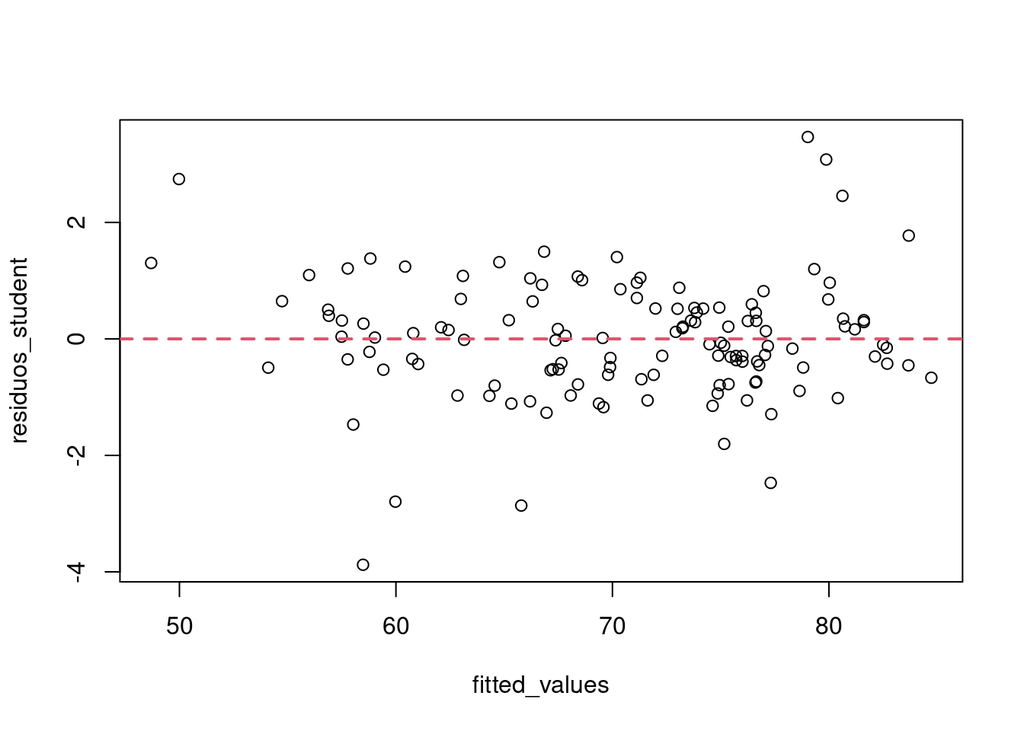

```r
plot(fitted_values, residuos_student); qqline(y=0, col = 2,lwd=2,lty=2)
```

```r
#--> Valores < -3 ou > 3:
Filter(function(x) abs(x) > 3, residuos_student)
```

```
##        12        99       108
##  3.467048  3.080329 -3.878255
```

Gráfico dffits vs índice, também com linha em zero:

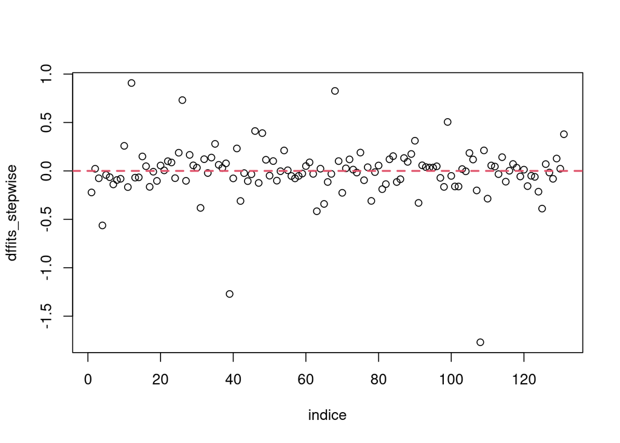

```r
plot(indice, dffits_stepwise); qqline(y=0, col = 2,lwd=2,lty=2)
```

```r
#--> Valores < -1 ou > 1:
Filter(function(x) abs(x) > 1, dffits_stepwise)
```

```
##        39       108
## -1.270852 -1.769369
```

Gráfico da distância de cook vs índice:

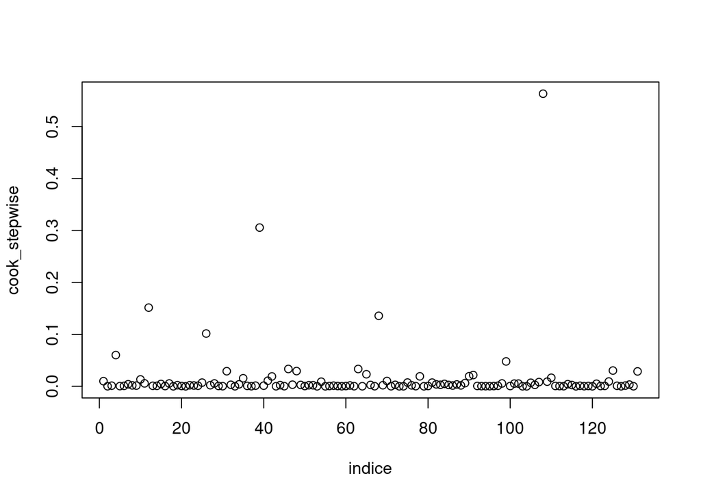

```r
plot(indice, cook_stepwise)
```